# Python Data Analysis - Final project

## Context

This final project is based on a real data analyst life scenario:

You’ve just been hired as a Data Analyst at “Home Credit”, a loan company, and a business owner comes to you.

Business Owner: “Hey you’re the new kid? Doing nerdy stuff eh? Here is some data for ya”.

*He hands you a USB key*

Business Owner: “You’re welcome. Now do some magic with it”.

[figure not shown]

*And then he stays there looking fixedly at your laptop screen…* *awkward silence* *It’s like he’s waiting for you to do something*

Alright the context is set, now you know what to do (or not). Let’s look at the data!

[figure not shown]

## Data

You find 8 csv files inside his USB device, along with a readme file describing which file is what :

- application_{train|test}.csv
  - This is the main table, broken into two files for Train (with TARGET) and Test (without TARGET).
  - Static data for all applications. One row represents one loan in our data sample.
- bureau.csv
  - All client's previous credits provided by other financial institutions that were reported to Credit Bureau (for clients who have a loan in our sample).
  - For every loan in our sample, there are as many rows as number of credits the client had in Credit Bureau before the application date.
- bureau_balance.csv
  - Monthly balances of previous credits in Credit Bureau.
  - This table has one row for each month of history of every previous credit reported to Credit Bureau – i.e the table has (#loans in sample *# of relative previous credits* # of months where we have some history observable for the previous credits) rows.
- POS_CASH_balance.csv
  - Monthly balance snapshots of previous POS (point of sales) and cash loans that the applicant had with Home Credit.
  - This table has one row for each month of history of every previous credit in Home Credit (consumer credit and cash loans) related to loans in our sample – i.e. the table has (#loans in sample *# of relative previous credits* # of months in which we have some history observable for the previous credits) rows.
- credit_card_balance.csv
  - Monthly balance snapshots of previous credit cards that the applicant has with Home Credit.
  - This table has one row for each month of history of every previous credit in Home Credit (consumer credit and cash loans) related to loans in our sample – i.e. the table has (#loans in sample *# of relative previous credit cards* # of months where we have some history observable for the previous credit card) rows.
- previous_application.csv
  - All previous applications for Home Credit loans of clients who have loans in our sample.
  - There is one row for each previous application related to loans in our data sample.
- installments_payments.csv
  - Repayment history for the previously disbursed credits in Home Credit related to the loans in our sample.
  - There is a) one row for every payment that was made plus b) one row each for missed payment.
- One row is equivalent to one payment of one installment OR one installment corresponding to one payment of one previous Home Credit credit related to loans in our sample.
- HomeCredit_columns_description.csv
  - This file contains descriptions for the columns in the various data files.

It looks like data about loan applications and applicants.

(This diagram gives you joining keys to merge datasets altogether)

[figure not shown]

Ok that dude has given us food for data scientists, you can tell because the application data is split into two files, one for training a predictive model and another one to test it. You’re not data scientist or madam Irma so you’re not going to predict anything. But you want this guy to know how good you are, he can’t tell the difference between data analysts and data scientists anyway.. We’re all data somethings to him, let’s teach him about Data Analysts!

As a Data Analyst you’re thing is to tell stories about data, stories no one ever told, and whether the story is true or not, you have to be convincing. So, let’s forget about the predicting thing and make him a story he’ll find interesting as a business owner.

The last file (HomeCredit_columns_description.csv) looks like a good start.

## Ok, funny.. seriously what should I do ?

Make a notebook telling interesting things about this data, tell a story (or many) using everything you learned. There are many hidden stories in data. You have to submit at least a notebook and any resources you used (like images or any other files).

Here are the criteria we will use to assess your work:

### Is it meaningful?

As a data analyst you have to produce something meaningful enough, just plotting random data is not going to work. Like a story your analysis should have some kind of logical progression.

### How well did you use the technical knowledge you’ve been taught?

Obviously, the way you use everything you learned during the lectures is going to be assessed.

### Cleanliness, aesthetics and clearness of your notebook

Is your analysis full of unused code? Is it difficult to read? Have you tried to make it easy and enjoyable to read?

### Innovation

Creativity, surprising things or any good initiatives you take are potential bonus points.

### Careful:

```
This work is individual, plagiarism is going to be measured by both machines and humans. Too many similarities between your work and any online or python buddy work will result in grade penalties.
```

Good Luck!

# Can we detect the most impactful features that influence the probability of an applicant to repay his loan ?

# I) Data overview

```python
#Importing necessary modules
import matplotlib.pyplot as plt
import pandas as pd
import numpy as np
import seaborn as sns
```

```python
import matplotlib.style as style
```

```python
#Having a first look at the main dataset
application_test = pd.read_csv("data/application_test.csv", index_col="SK_ID_CURR")
application_train = pd.read_csv("data/application_train.csv", index_col="SK_ID_CURR")
application_train.head(5)
```

| SK_ID_CURR | TARGET | NAME_CONTRACT_TYPE | CODE_GENDER | FLAG_OWN_CAR | FLAG_OWN_REALTY | CNT_CHILDREN | AMT_INCOME_TOTAL | AMT_CREDIT | AMT_ANNUITY | AMT_GOODS_PRICE | ... | FLAG_DOCUMENT_18 | FLAG_DOCUMENT_19 | FLAG_DOCUMENT_20 | FLAG_DOCUMENT_21 | AMT_REQ_CREDIT_BUREAU_HOUR | AMT_REQ_CREDIT_BUREAU_DAY | AMT_REQ_CREDIT_BUREAU_WEEK | AMT_REQ_CREDIT_BUREAU_MON | AMT_REQ_CREDIT_BUREAU_QRT | AMT_REQ_CREDIT_BUREAU_YEAR |
| --- | --- | --- | --- | --- | --- | --- | --- | --- | --- | --- | --- | --- | --- | --- | --- | --- | --- | --- | --- | --- | --- |
| 100002 | 1 | Cash loans | M | N | Y | 0 | 202500.0 | 406597.5 | 24700.5 | 351000.0 | ... | 0 | 0 | 0 | 0 | 0.0 | 0.0 | 0.0 | 0.0 | 0.0 | 1.0 |
| 100003 | 0 | Cash loans | F | N | N | 0 | 270000.0 | 1293502.5 | 35698.5 | 1129500.0 | ... | 0 | 0 | 0 | 0 | 0.0 | 0.0 | 0.0 | 0.0 | 0.0 | 0.0 |
| 100004 | 0 | Revolving loans | M | Y | Y | 0 | 67500.0 | 135000.0 | 6750.0 | 135000.0 | ... | 0 | 0 | 0 | 0 | 0.0 | 0.0 | 0.0 | 0.0 | 0.0 | 0.0 |
| 100006 | 0 | Cash loans | F | N | Y | 0 | 135000.0 | 312682.5 | 29686.5 | 297000.0 | ... | 0 | 0 | 0 | 0 | NaN | NaN | NaN | NaN | NaN | NaN |
| 100007 | 0 | Cash loans | M | N | Y | 0 | 121500.0 | 513000.0 | 21865.5 | 513000.0 | ... | 0 | 0 | 0 | 0 | 0.0 | 0.0 | 0.0 | 0.0 | 0.0 | 0.0 |

5 rows × 121 columns

```python
application_train.TARGET.value_counts()/len(application_train)
```

```
0    0.919271
1    0.080729
Name: TARGET, dtype: float64
```

8% of the sample did not repay their loan in time

```python
#Let's create a copy to avoid conflicts when modifying the dataset
application_train = application_train.copy()
```

```python
#This dataset will be used in Excel to see all the columns meanings at a quick glance
columns_description = pd.read_csv("data/HomeCredit_columns_description.csv", encoding='ISO-8859-1')
columns_description.head(5)
```

|  | Unnamed: 0 | Table | Row | Description | Special |
| --- | --- | --- | --- | --- | --- |
| 0 | 1 | application_{train\|test}.csv | SK_ID_CURR | ID of loan in our sample | NaN |
| 1 | 2 | application_{train\|test}.csv | TARGET | Target variable (1 - client with payment diffi... | NaN |
| 2 | 5 | application_{train\|test}.csv | NAME_CONTRACT_TYPE | Identification if loan is cash or revolving | NaN |
| 3 | 6 | application_{train\|test}.csv | CODE_GENDER | Gender of the client | NaN |
| 4 | 7 | application_{train\|test}.csv | FLAG_OWN_CAR | Flag if the client owns a car | NaN |

##### Rough picture of missing data

```python
# A quarter of the columns have a lot of missing data, but half of them are complete at least
round(application_train.isna().sum()*100 /len(application_train),0).sort_values(ascending=False).describe()
```

```
count    122.000000
mean      24.360656
std       28.394524
min        0.000000
25%        0.000000
50%        0.000000
75%       51.000000
max       70.000000
dtype: float64
```

```python
round(application_train.isna().sum()*100 /len(application_train),0).sort_values(ascending=False).head(20)
# Columns where there is a lot of missing data
```

```
COMMONAREA_MODE             70.0
COMMONAREA_MEDI             70.0
COMMONAREA_AVG              70.0
NONLIVINGAPARTMENTS_MEDI    69.0
NONLIVINGAPARTMENTS_MODE    69.0
NONLIVINGAPARTMENTS_AVG     69.0
LIVINGAPARTMENTS_MEDI       68.0
FLOORSMIN_MEDI              68.0
FONDKAPREMONT_MODE          68.0
FLOORSMIN_AVG               68.0
LIVINGAPARTMENTS_MODE       68.0
LIVINGAPARTMENTS_AVG        68.0
FLOORSMIN_MODE              68.0
YEARS_BUILD_MEDI            66.0
OWN_CAR_AGE                 66.0
YEARS_BUILD_MODE            66.0
YEARS_BUILD_AVG             66.0
LANDAREA_MEDI               59.0
LANDAREA_MODE               59.0
LANDAREA_AVG                59.0
dtype: float64
```

```python
#If we have a doubt on a variable type
types = application_train.dtypes
types
```

[output not shown]

# II) Exploring correlations with "TARGET"

## a) Correlation matrix

```python
# Extracting most important correlations between application_train columns and target
correl = application_train.corr()['TARGET'].sort_values()
```

```python
correl.head(10)
```

```
EXT_SOURCE_3                 -0.178919
EXT_SOURCE_2                 -0.160472
EXT_SOURCE_1                 -0.155317
DAYS_EMPLOYED                -0.044932
FLOORSMAX_AVG                -0.044003
FLOORSMAX_MEDI               -0.043768
FLOORSMAX_MODE               -0.043226
AMT_GOODS_PRICE              -0.039645
REGION_POPULATION_RELATIVE   -0.037227
ELEVATORS_AVG                -0.034199
Name: TARGET, dtype: float64
```

```python
correl.tail(10)
```

```
FLAG_DOCUMENT_3                0.044346
REG_CITY_NOT_LIVE_CITY         0.044395
FLAG_EMP_PHONE                 0.045982
REG_CITY_NOT_WORK_CITY         0.050994
DAYS_ID_PUBLISH                0.051457
DAYS_LAST_PHONE_CHANGE         0.055218
REGION_RATING_CLIENT           0.058899
REGION_RATING_CLIENT_W_CITY    0.060893
DAYS_BIRTH                     0.078239
TARGET                         1.000000
Name: TARGET, dtype: float64
```

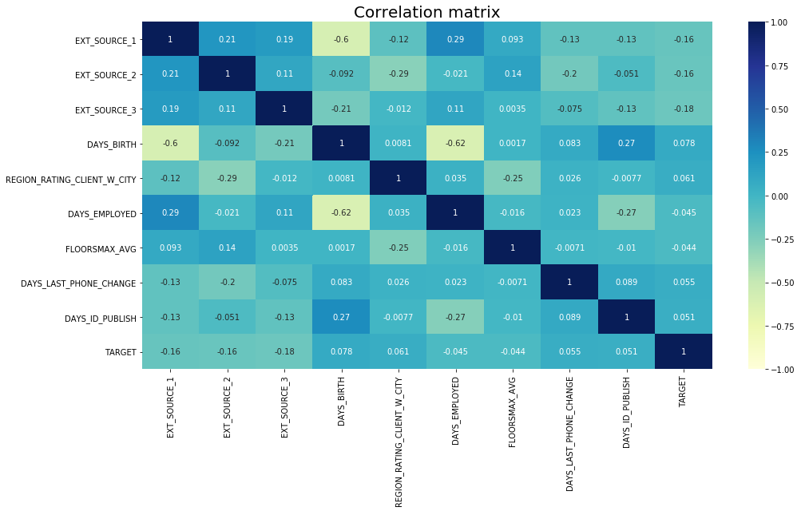

```python
#Heatmap to visualize correlations and try to explain EXT_SOURCE variables
heatmap_correlations = application_train[['EXT_SOURCE_1', "EXT_SOURCE_2", "EXT_SOURCE_3", "DAYS_BIRTH", "REGION_RATING_CLIENT_W_CITY", "DAYS_EMPLOYED","FLOORSMAX_AVG", "DAYS_LAST_PHONE_CHANGE", "DAYS_ID_PUBLISH", "TARGET"]].corr()
plt.figure(figsize=(16,8))
sns.heatmap(heatmap_correlations, vmin=-1, vmax=1, annot=True, cmap="YlGnBu")
plt.title("Correlation matrix", fontsize=20, fontweight=20)
```

As we can vizualise on the following heatmap, the top 3 correlations with Target are the EXT_SOURCE variables. Age, is strongly correlated with EXT_SOURCE_1 so we can look at it closer.

## b) Let's zoom on age

```python
#Let's first have a look at the distribution to create bins
application_train["age"] = np.round(-application_train.DAYS_BIRTH/365,0)
application_train.age.describe()
```

```
count    307511.000000
mean         43.938646
std          11.964047
min          21.000000
25%          34.000000
50%          43.000000
75%          54.000000
max          69.000000
Name: age, dtype: float64
```

```python
# Creating 5 years age categories to have a global overview of the data
bins = [20,25,30,35,40,45,50,55,60,65,70]
labels = ["20-25", "25-30", "30-35", "35-40", "40-45", "45-50", "50-55", "55-60", "60-65", "65-70"]
application_train['age_bins'] = pd.cut(application_train.age, bins=bins, labels=labels)
```

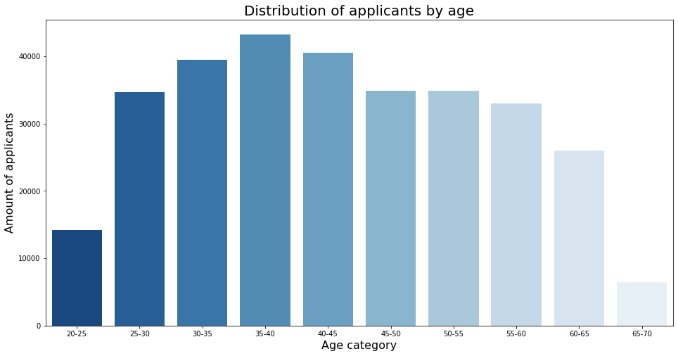

```python
f, ax = plt.subplots(figsize=(16,8))
sns.countplot(data=application_train, x="age_bins", palette ="Blues_r", ax=ax)
plt.xlabel("Age category", fontsize=16)
plt.ylabel("Amount of applicants", fontsize=16)
plt.title("Distribution of applicants by age", fontsize=20, fontweight=20)
```

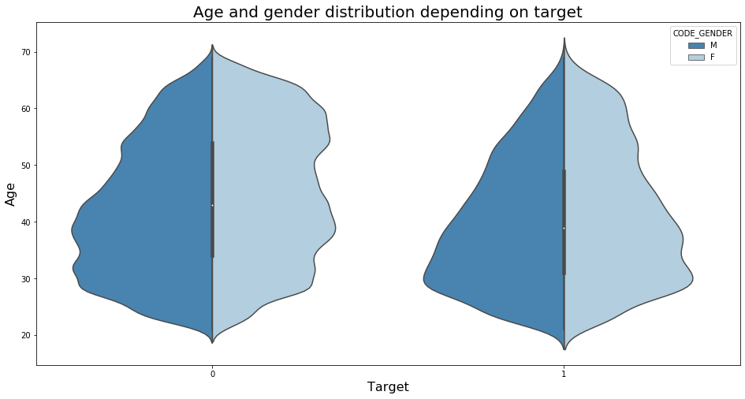

```python
fig, ax = plt.subplots(figsize=(16,8))
sns.violinplot(x='TARGET', y="age", hue='CODE_GENDER', split=True, data=application_train, ax=ax, palette='Blues_r')
plt.xlabel("Target", fontsize=16)
plt.ylabel("Age", fontsize=16)
plt.title("Age and gender distribution depending on target", fontsize=20, fontweight=20)
```

Looks like there is a greater density around the age of 30 for people who do not repay their loan in time

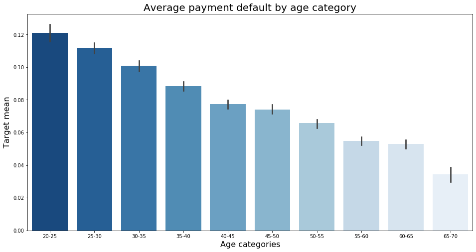

```python
g, ax2 = plt.subplots(figsize=(16,8))
sns.barplot(x="age_bins", y='TARGET', data=application_train, palette='Blues_r', ax=ax2)
plt.xlabel("Age categories", fontsize=16)
plt.ylabel("Target mean", fontsize=16)
plt.title("Average payment default by age category", fontsize=20, fontweight=20)
```

Indeed the younger, the higher the default payment rate : 12% of applicants between 20 and 25 do not repay in time while less than 4% of applicants between 65 and 70 fail to repay their loan.

## c) What about region/city rating ?

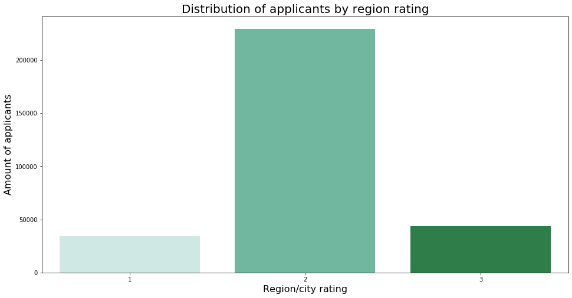

```python
f, ax = plt.subplots(figsize=(16,8))
sns.countplot(data=application_train, x="REGION_RATING_CLIENT_W_CITY", palette ="BuGn", ax=ax)
plt.xlabel("Region/city rating", fontsize=16)
plt.ylabel("Amount of applicants", fontsize=16)
plt.title("Distribution of applicants by region rating", fontsize=20, fontweight=20)
```

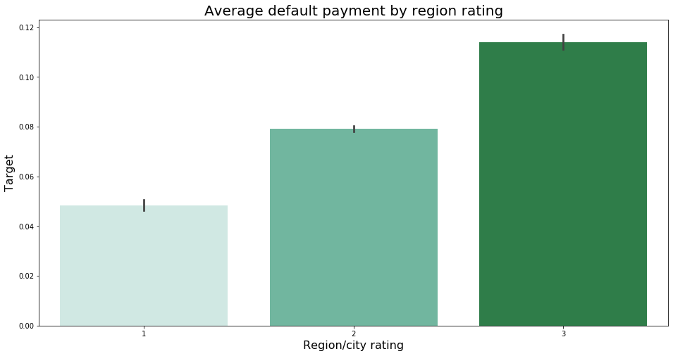

```python
fig, ax = plt.subplots(figsize=(16,8))
sns.barplot(x="REGION_RATING_CLIENT_W_CITY",y="TARGET", data=application_train, ax=ax, palette="BuGn")
plt.xlabel("Region/city rating", fontsize=16)
plt.ylabel("Target", fontsize=16)
plt.title("Average default payment by region rating", fontsize=20, fontweight=20)
```

There is a consequent gap between regions rated 1 with a very low mean of target (hence few repayment delays) and regions rated 3 with more than 1 default per 10 applicants.

## d) Influence of employment duration

```python
application_train.DAYS_EMPLOYED.describe()
# There is an incoherent value as values must be negative or null
```

```
count    307511.000000
mean      63815.045904
std      141275.766519
min      -17912.000000
25%       -2760.000000
50%       -1213.000000
75%        -289.000000
max      365243.000000
Name: DAYS_EMPLOYED, dtype: float64
```

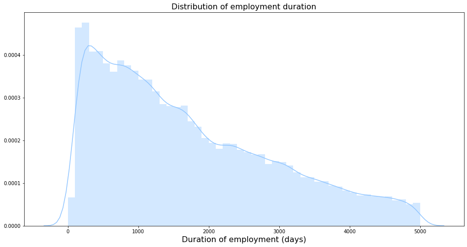

```python
#Let's zoom on the most interesting area
fig, ax = plt.subplots(figsize=(16,8))
sns.distplot(-application_train.DAYS_EMPLOYED[application_train.DAYS_EMPLOYED<50000][application_train.DAYS_EMPLOYED> -5000], ax=ax)
plt.xlabel("Duration of employment (days)", fontsize=16)
plt.title("Distribution of employment duration", fontsize=16, fontweight=20)
```

```python
# We can create bins to transform the continuous variable into caterogical data to see if there is a trend emerging
bins = [-5000, -4000, -3000, -2000, -1000,0]
labels = ["14-11", "11-8", "8-5", "5-3", "3-0"]
application_train["years_employment"] = pd.cut(application_train.DAYS_EMPLOYED, bins=bins, labels=labels)
```

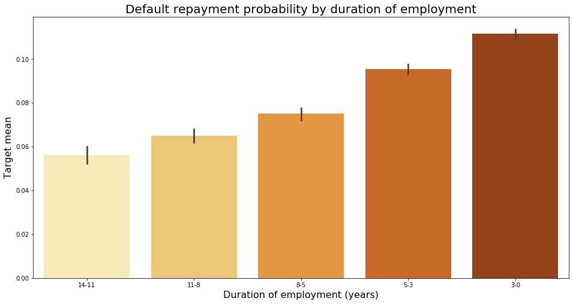

```python
fig, ax = plt.subplots(figsize=(16,8))
sns.barplot(data=application_train, x="years_employment", y="TARGET", palette="YlOrBr", ax=ax)
plt.xlabel("Duration of employment (years)", fontsize=16)
plt.ylabel("Target mean", fontsize=16)
plt.title("Default repayment probability by duration of employment", fontsize=20, fontweight=20)
```

# III) Digging in hidden correlations with relevant categorical variables

## a) Gender

```python
# 2/3 are women and 1/3 are men
application_train.CODE_GENDER.value_counts()/len(application_train)
```

[output not shown]

```python
#There are only 4 "other" values we can withdraw because of the size of the dataset
application_train = application_train[application_train.CODE_GENDER != "XNA"]
```

```python
application_train['CODE_GENDER'].map({"M":0, "F":1}).corr(application_train['TARGET'])
```

```
-0.05471012101772606
```

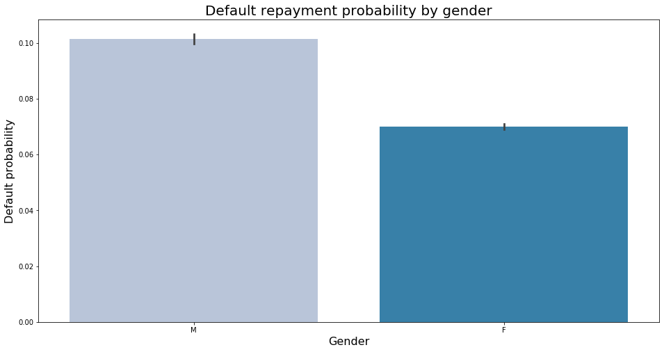

```python
fig, ax = plt.subplots(figsize=(16,8))
sns.barplot(x="CODE_GENDER", y ="TARGET", data=application_train, palette='PuBu', ax=ax)
plt.xlabel("Gender", fontsize=16)
plt.ylabel("Default probability", fontsize=16)
plt.title("Default repayment probability by gender", fontsize=20, fontweight=20)
```

It seems that men tend to be worse loan applicants than women

## b) Occupation and income

```python
#We are also interested in the revenue generated with the occupation
application_train.AMT_INCOME_TOTAL.describe()
```

```
count    3.075070e+05
mean     1.687977e+05
std      2.371246e+05
min      2.565000e+04
25%      1.125000e+05
50%      1.471500e+05
75%      2.025000e+05
max      1.170000e+08
Name: AMT_INCOME_TOTAL, dtype: float64
```

```python
#Let's create two categories of income to plot it with occupation
bins = [0,1.471500e+05,1.170000e+08]
labels = ["lower_income", "greater_income"]
application_train["income_cat"] = pd.cut(application_train.AMT_INCOME_TOTAL, bins=bins, labels=labels)
```

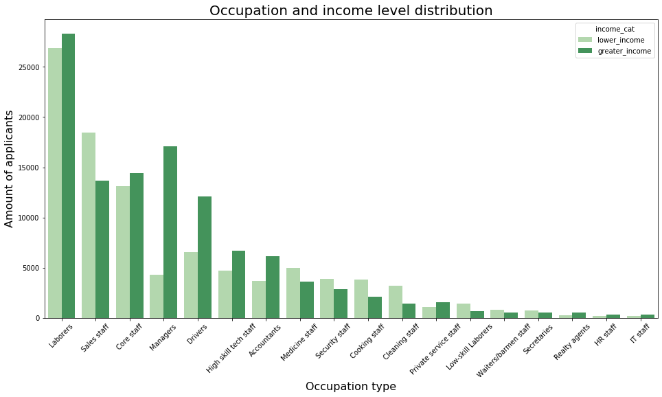

```python
f, ax = plt.subplots(figsize=(16,8))
sns.countplot(x="OCCUPATION_TYPE",hue="income_cat", data=application_train, palette="Greens", order=application_train.OCCUPATION_TYPE.value_counts().index, ax=ax)
plt.xlabel("Occupation type", fontsize=16)
plt.xticks(rotation=45)
plt.ylabel("Amount of applicants", fontsize=16)
plt.title("Occupation and income level distribution", fontsize=20, fontweight=20)
```

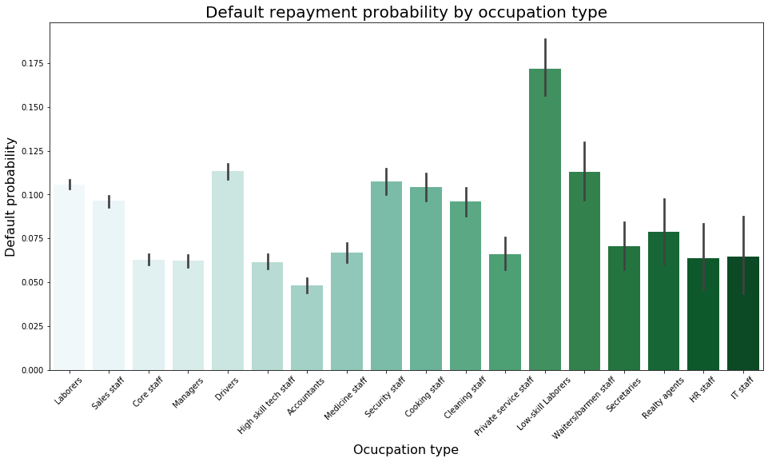

```python
fig, ax = plt.subplots(figsize=(16,8))
sns.barplot(x="OCCUPATION_TYPE",y="TARGET", data=application_train, ax=ax, palette="BuGn", order=application_train.OCCUPATION_TYPE.value_counts().index)
plt.xticks(rotation=45)
plt.xlabel("Ocucpation type", fontsize=16)
plt.ylabel("Default probability", fontsize=16)
plt.title("Default repayment probability by occupation type", fontsize=20, fontweight=20)
```

We learn from these two graphs that the ability to repay a loan in time does not necessarly depend on the total income of the applicant. Indeed most drivers belong to the 2nd half in terms of income though they are in the top 3 occupations which tend to have more repayment default.

Moreover, we can clearly see that occupation is a feature that can influence quite a lot on the probability to repay. For example low-skill laborers have 3 times more default payment than accounts in average.

## c) Family status

```python
application_train = application_train[application_train.NAME_FAMILY_STATUS != "Unknown"]
```

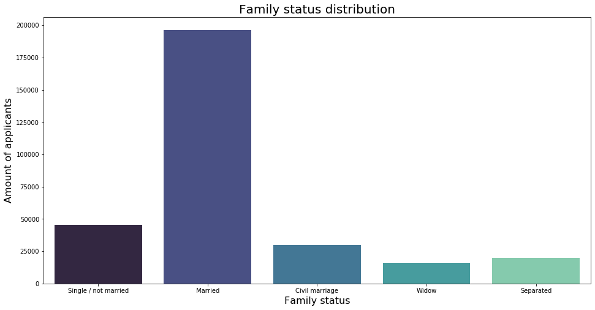

```python
# Most of the applicants are married
f, ax = plt.subplots(figsize=(16,8))
sns.countplot(x="NAME_FAMILY_STATUS", data=application_train, palette="mako", ax=ax)
plt.xlabel("Family status", fontsize=16)
plt.ylabel("Amount of applicants", fontsize=16)
plt.title("Family status distribution", fontsize=20, fontweight=20)
```

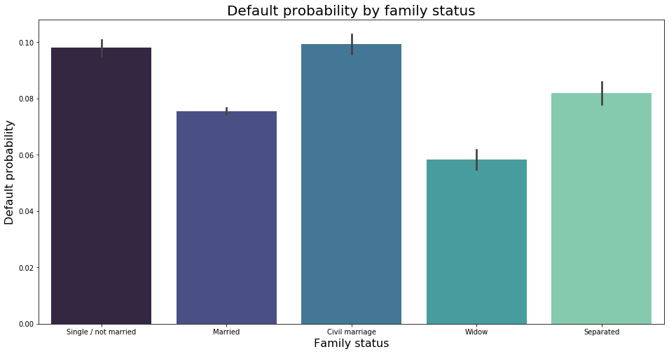

```python
fig, ax = plt.subplots(figsize=(16,8))
sns.barplot(x="NAME_FAMILY_STATUS",y="TARGET", data=application_train, ax=ax, palette="mako")
plt.xlabel("Family status", fontsize=16)
plt.ylabel("Default probability", fontsize=16)
plt.title("Default probability by family status", fontsize=20, fontweight=20)
```

## d) Day of the week

```python
# Repartition of days people take their loan
round(application_train.WEEKDAY_APPR_PROCESS_START.value_counts()/len(application_train),2)
```

```
TUESDAY      0.18
WEDNESDAY    0.17
MONDAY       0.16
THURSDAY     0.16
FRIDAY       0.16
SATURDAY     0.11
SUNDAY       0.05
Name: WEEKDAY_APPR_PROCESS_START, dtype: float64
```

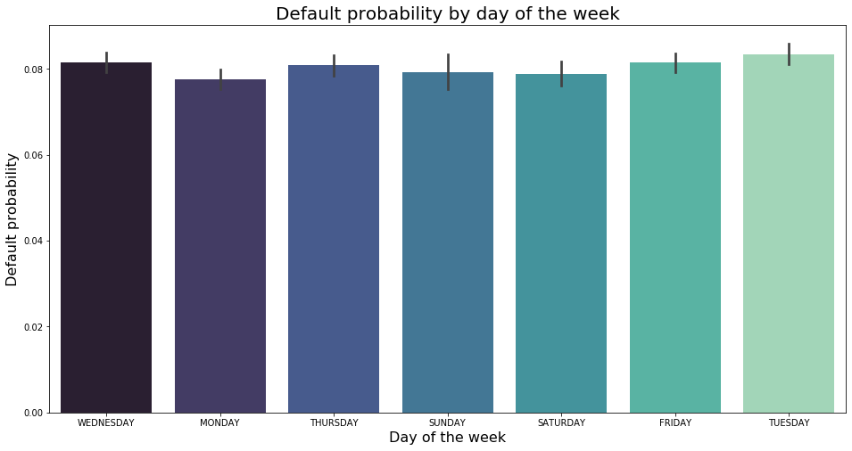

```python
fig, ax = plt.subplots(figsize=(16,8))
sns.barplot(x="WEEKDAY_APPR_PROCESS_START",y="TARGET", data=application_train, ax=ax, palette="mako")
plt.xlabel("Day of the week", fontsize=16)
plt.ylabel("Default probability", fontsize=16)
plt.title("Default probability by day of the week", fontsize=20, fontweight=20)
```

Day of the week does not seem to have any influence on the probability to repay

## e) Hour of the day

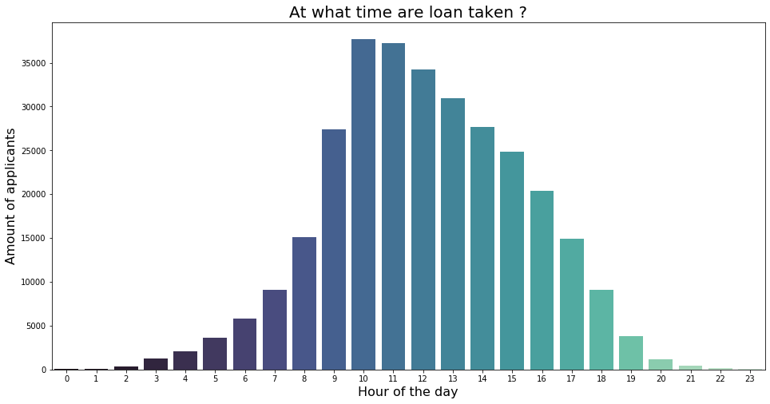

```python
f, ax = plt.subplots(figsize=(16,8))
sns.countplot(x="HOUR_APPR_PROCESS_START", data=application_train, palette="mako", ax=ax)
plt.xlabel("Hour of the day", fontsize=16)
plt.ylabel("Amount of applicants", fontsize=16)
plt.title("At what time are loan taken ?", fontsize=20, fontweight=20)
```

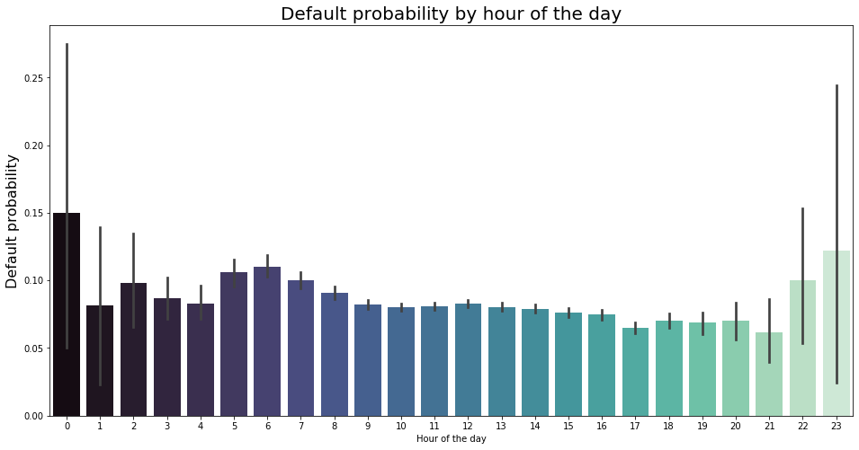

```python
fig, ax = plt.subplots(figsize=(16,8))
sns.barplot(x="HOUR_APPR_PROCESS_START",y="TARGET", data=application_train, ax=ax, palette="mako")
plt.xlabel("Hour of the day")
plt.ylabel("Default probability", fontsize=16)
plt.title("Default probability by hour of the day", fontsize=20, fontweight=20)
```

Time at which the loan is taken is not relevant because the gap we notice at 23 and 0 are due to a very small amount of data, hence the huge variance so it does mean anything.

# IV) Let's join application_train with other datasets to see if we can extract more relevant features. We'll compute the correlations with target directly.

## a) Bureau

```python
bureau = pd.read_csv("data/bureau.csv", index_col="SK_ID_CURR")
app_join_bureau = bureau.join(application_train[['TARGET']],on="SK_ID_CURR", how='inner')
corr_target_bureau = app_join_bureau.corr()['TARGET'].sort_values(ascending=False)
corr_target_bureau
# DAYS_CREDIT is worth digging in as its correlation with target is one of the greatest
```

```
TARGET                    1.000000
DAYS_CREDIT               0.061556
DAYS_CREDIT_UPDATE        0.041077
DAYS_ENDDATE_FACT         0.039057
DAYS_CREDIT_ENDDATE       0.026497
AMT_CREDIT_SUM_OVERDUE    0.006253
CREDIT_DAY_OVERDUE        0.002652
AMT_CREDIT_SUM_DEBT       0.002539
AMT_CREDIT_MAX_OVERDUE    0.001587
CNT_CREDIT_PROLONG        0.001523
AMT_ANNUITY               0.000117
AMT_CREDIT_SUM_LIMIT     -0.005990
SK_ID_BUREAU             -0.009018
AMT_CREDIT_SUM           -0.010606
Name: TARGET, dtype: float64
```

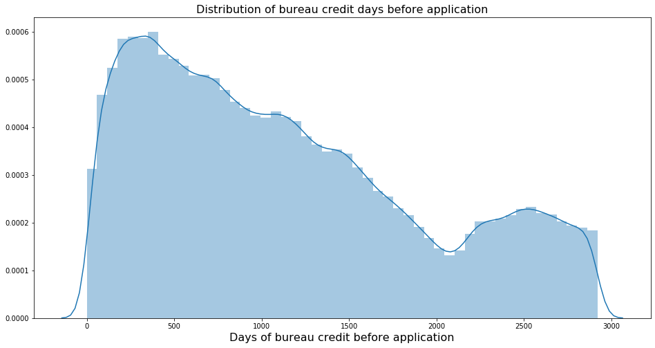

```python
fig, ax = plt.subplots(figsize=(16,8))
sns.distplot(-bureau.DAYS_CREDIT, ax=ax)
plt.xlabel("Days of bureau credit before application", fontsize=16)
plt.title("Distribution of bureau credit days before application", fontsize=16, fontweight=20)
```

```python
bins = [0, 365, 365*2, 365*3, 365*4, 365*5, 365*6, 365*7, 365*8.3]
labels = ["0-1", "1-2", "2-3", "3-4", "4-5", "5-6", "6-7", "7-8"]
app_join_bureau["years_bureau_credit"] = pd.cut(-app_join_bureau.DAYS_CREDIT, bins=bins, labels=labels)
```

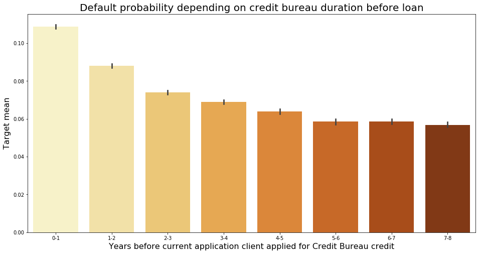

```python
fig, ax = plt.subplots(figsize=(16,8))
sns.barplot(data=app_join_bureau, x="years_bureau_credit", y="TARGET", palette="YlOrBr", ax=ax)
plt.xlabel("Years before current application client applied for Credit Bureau credit", fontsize=16)
plt.ylabel("Target mean", fontsize=16)
plt.title("Default probability depending on credit bureau duration before loan", fontsize=20, fontweight=20)
```

Applicants who applied for a Credit Bureau credit for more than 5 years are more reliable than others.

## b) Credit card balance

```python
credit_card_balance = pd.read_csv("data/credit_card_balance.csv", index_col="SK_ID_CURR")
credit_card_join_app = credit_card_balance.join(application_train[["TARGET"]],on="SK_ID_CURR", how="inner")
credit_corr = credit_card_join_app.corr()["TARGET"].sort_values(ascending=False)
credit_corr
```

```
TARGET                        1.000000
AMT_BALANCE                   0.050098
AMT_TOTAL_RECEIVABLE          0.049839
AMT_RECIVABLE                 0.049803
AMT_RECEIVABLE_PRINCIPAL      0.049692
AMT_INST_MIN_REGULARITY       0.039798
CNT_DRAWINGS_ATM_CURRENT      0.038437
CNT_DRAWINGS_CURRENT          0.037793
MONTHS_BALANCE                0.035695
CNT_DRAWINGS_POS_CURRENT      0.029536
AMT_DRAWINGS_ATM_CURRENT      0.024700
AMT_DRAWINGS_CURRENT          0.022378
AMT_CREDIT_LIMIT_ACTUAL       0.013823
AMT_PAYMENT_CURRENT           0.012929
AMT_PAYMENT_TOTAL_CURRENT     0.012302
SK_DPD_DEF                    0.010538
AMT_DRAWINGS_POS_CURRENT      0.005084
AMT_DRAWINGS_OTHER_CURRENT    0.003843
CNT_DRAWINGS_OTHER_CURRENT    0.003044
SK_ID_PREV                    0.002571
SK_DPD                        0.001684
CNT_INSTALMENT_MATURE_CUM    -0.023684
Name: TARGET, dtype: float64
```

## c) Installments payments

```python
installments_payments = pd.read_csv("data/installments_payments.csv", index_col="SK_ID_CURR")
installments_payments_join_app = installments_payments.join(application_train[["TARGET"]],on="SK_ID_CURR", how="inner")
install_corr = installments_payments_join_app.corr()["TARGET"].sort_values(ascending=False)
install_corr
```

```
TARGET                    1.000000
DAYS_ENTRY_PAYMENT        0.035123
DAYS_INSTALMENT           0.034975
SK_ID_PREV               -0.000210
AMT_INSTALMENT           -0.001498
AMT_PAYMENT              -0.003623
NUM_INSTALMENT_VERSION   -0.009895
NUM_INSTALMENT_NUMBER    -0.016193
Name: TARGET, dtype: float64
```

## d) Cash balance

```python
cash_balance = pd.read_csv("data/POS_CASH_balance.csv", index_col="SK_ID_CURR")
cash_balance.head(5)
cash_balance_join_app = cash_balance.join(application_train[["TARGET"]],on="SK_ID_CURR", how="inner")
cash_corr = cash_balance_join_app.corr()["TARGET"].sort_values(ascending=False)
cash_corr
```

```
TARGET                   1.000000
CNT_INSTALMENT_FUTURE    0.021973
MONTHS_BALANCE           0.020148
CNT_INSTALMENT           0.018506
SK_DPD                   0.009866
SK_DPD_DEF               0.008594
SK_ID_PREV              -0.000055
Name: TARGET, dtype: float64
```

## e) Previous application

```python
previous_application = pd.read_csv("data/previous_application.csv", index_col="SK_ID_CURR")
previous_application.head(5)
previous_app_join_app = previous_application.join(application_train[["TARGET"]],on="SK_ID_CURR", how="inner")
prev_corr = previous_app_join_app.corr()["TARGET"].sort_values(ascending=False)
prev_corr
```

```
TARGET                       1.000000
DAYS_DECISION                0.039903
CNT_PAYMENT                  0.030479
RATE_INTEREST_PRIVILEGED     0.028640
DAYS_LAST_DUE_1ST_VERSION    0.018019
DAYS_LAST_DUE                0.017522
DAYS_TERMINATION             0.016981
SK_ID_PREV                   0.002013
NFLAG_INSURED_ON_APPROVAL    0.000656
AMT_GOODS_PRICE              0.000255
RATE_INTEREST_PRIMARY       -0.001470
AMT_CREDIT                  -0.002349
SELLERPLACE_AREA            -0.002539
NFLAG_LAST_APPL_IN_DAY      -0.002886
AMT_APPLICATION             -0.005581
DAYS_FIRST_DUE              -0.006652
AMT_ANNUITY                 -0.014922
AMT_DOWN_PAYMENT            -0.016918
RATE_DOWN_PAYMENT           -0.026111
HOUR_APPR_PROCESS_START     -0.027805
DAYS_FIRST_DRAWING          -0.031152
Name: TARGET, dtype: float64
```

We have extracted relevant features to predict if one is likely to repay his loan in time. Let's sum up what we've learned so far.

# V) Analysis summary

## With the insights we found we have a rough picture of who are the best and worst loan applicants :

### Caracteristics of applicants who fail to repay their loan in time more than average :

- Between 20 and 30-35 years old
- Located in a city belonging to a region graded 3
- Working for less than 5 years
- Male
- Having one of the following occupations : Low-skill laborer, Laborer, Driver, Security staff, Cooking staff, Waiter/barmen
- Having a Credit Bureau credit for less than 2 years

### Caracteristics of applicants who are the most reliable in average :

- More than 55 years old
- In a region rated 1
- Working for more than 8 years
- Female
- Having one of the following occupations : Accountant, Manager, Core staff, High skill tech staff, Medecine staff
- Having a Credit Bureau credit for more than 5 years

### These caracteristics have to be taken separatly, they are not necessarly correlated with each other as far as we know.

# VI) Building a machine learning model with our relevant features

## Random Forest Classifier

```python
from sklearn.ensemble import RandomForestClassifier
```

```python
# We need to withdraw NA values to use the data in our machine learning model
application_ml = application_train.dropna()
```

```python
from sklearn.model_selection import train_test_split
X = application_ml[["age", "DAYS_EMPLOYED", "EXT_SOURCE_1", "EXT_SOURCE_2", "EXT_SOURCE_3", "REGION_RATING_CLIENT_W_CITY"]]
y = application_ml["TARGET"]
X_train, X_test, y_train, y_test = train_test_split(X, y, test_size=0.3)
```

```python
#Number of trees in the forest (100 is default)
clf=RandomForestClassifier(n_estimators=100)
#Train the model using the training sets
clf.fit(X_train,y_train)

y_pred=clf.predict(X_test)
```

```python
#Import metrics module for accuracy computation
from sklearn import metrics
```

```python
# Model Accuracy: what is the percentage of correct predictions ?
print("Accuracy:",metrics.accuracy_score(y_test, y_pred))
```

```
Accuracy: 0.9414955443626501
```

We have a 94% accuracy model but we do not take every categories into account. Moreover if we have too many loss on validation test it would mean that our model is overfitting and would have become too specific.